# Week 5

# 1 Tidymodels

By now, we have looked at broom (tidy, glance, augment), rsample (splitting data), parsnip (specifying models), and yardstick (evaluating models).

## 1.1 Workflows

We are now going to look at starting to put together all the pieces into a coherent workflow, similar to how you might chain mutate/group by/summarize/left join/etc in tidyverse as one step.

We are continuing to build our modeling pipeline.

Figure 1.3:

[figure not shown]

Now let’s introduce the model workflow. We won’t really see the benefit of using this until we start using a lot of different models.

```r
lm_model <-
  linear_reg() %>%
  set_engine("lm")

lm_wflow <-
  workflow() %>%
  add_model(lm_model)

data(ames)

ames <- ames %>% mutate(Sale_Price = log10(Sale_Price))

set.seed(123)
ames_split <- initial_split(ames, prop = 0.80, strata = Sale_Price)
ames_train <- training(ames_split)
ames_test  <-  testing(ames_split)

lm_model <- linear_reg() %>% set_engine("lm")

lm_wflow <-
  workflow() %>%
  add_model(lm_model) %>%
  add_formula(Sale_Price ~ Longitude + Latitude)

lm_fit <- fit(lm_wflow, ames_train)
```

## 1.2 Recipies

A recipe is also an object that defines a series of steps for data processing. Unlike the formula method inside a modeling function, the recipe defines the steps without immediately executing them; it is only a specification of what should be done. ~ Sec 8.1

Here’s the example from the textbook:

```r
simple_ames <-
  recipe(Sale_Price ~ Neighborhood + Gr_Liv_Area + Year_Built + Bldg_Type,
         data = ames_train) %>% #data is used here for column types only
  step_log(Gr_Liv_Area, base = 10) %>%
  step_dummy(all_nominal_predictors())
simple_ames
```

```
## Recipe
##
## Inputs:
##
##       role #variables
##    outcome          1
##  predictor          4
##
## Operations:
##
## Log transformation on Gr_Liv_Area
## Dummy variables from all_nominal_predictors()
```

Another key point from 8.3, all preprocessing/feature engineering steps only use the training data. Otherwise, your model might utilize information leakage and lead to overfitting.

There’s a ton of different recipe steps

Let’s go back and look at the divvy data and see how we could use a recipe for data processing. Recall the example from class…

Key steps:

1. Process recipe using training data
2. Apply recipe using training data
3. Apply recipe to testing

```r
divvy_data <- read_csv('https://github.com/erhla/pa470spring2022/raw/main/static/lectures/week_3_data.csv')

grouped <- rsample::initial_split(divvy_data)
train <- training(grouped)
test  <- testing(grouped)


lm_model <-
  parsnip::linear_reg() %>%
  set_engine("lm") %>%
  set_mode('regression')

divvy_rec <- recipe(rides ~ ., data=train)

divvy_rec
```

```
## Recipe
##
## Inputs:
##
##       role #variables
##    outcome          1
##  predictor          7
```

```r
divvy_rec <- recipe(rides ~ solar_rad + started_hour +
           temp + wind + interval_rain + avg_speed, data=train) %>%
  step_mutate(hour = factor(hour(started_hour))) %>%
  step_date(started_hour, features=c("dow", "month")) %>%
  step_holiday(started_hour, holidays = timeDate::listHolidays("US"),
               keep_original_cols = FALSE) %>%
  step_dummy(all_nominal_predictors())


#divvy_rec %>% prep() %>% bake(test) %>% view()

divvy_workflow <-
  workflow() %>%
  add_model(lm_model) %>%
  add_recipe(divvy_rec)

divvy_workflow
```

```
## ══ Workflow ════════════════════════════════════════════════════════════════════
## Preprocessor: Recipe
## Model: linear_reg()
##
## ── Preprocessor ────────────────────────────────────────────────────────────────
## 4 Recipe Steps
##
## • step_mutate()
## • step_date()
## • step_holiday()
## • step_dummy()
##
## ── Model ───────────────────────────────────────────────────────────────────────
## Linear Regression Model Specification (regression)
##
## Computational engine: lm
```

```r
divvy_fit <- divvy_workflow %>%
  fit(data=train)

divvy_fit %>% tidy() %>% view()

divvy_preds <-
  augment(divvy_fit, test)
```

Recall that our simple model had a MAPE of 136 and a RMSE of 352.

```
solar_rad + factor(hour(started_hour)) +
           factor(wday(started_hour)) +
           factor(month(started_hour)) +
           temp + wind + interval_rain + avg_speed
```

This is essentially the same model

```r
divvy_fit %>% extract_fit_parsnip() %>% tidy()
```

| term | estimate | std.error | statistic | p.value |
| --- | --- | --- | --- | --- |
| (Intercept) | 1678.0108554 | 166.56727693 | 10.07407269 | 1.493424e-23 |
| solar_rad | 0.9409949 | 0.04595032 | 20.47852554 | 3.704097e-88 |
| temp | 17.9202663 | 1.45230564 | 12.33918382 | 2.811019e-34 |
| wind | -29.6243234 | 5.70018908 | -5.19707732 | 2.139369e-07 |
| interval_rain | -125.5217163 | 10.96280275 | -11.44978334 | 7.881821e-30 |
| avg_speed | -61.1437651 | 5.71911585 | -10.69112197 | 2.817305e-26 |
| started_hour_USChristmasDay | -469.5217633 | 82.48504326 | -5.69220485 | 1.356475e-08 |
| started_hour_USColumbusDay | -234.2909005 | 93.75079805 | -2.49908167 | 1.249669e-02 |
| started_hour_USCPulaskisBirthday | NA | NA | NA | NA |
| started_hour_USDecorationMemorialDay | NA | NA | NA | NA |

[output cut: 54 more lines]

```r
yardstick::mape(divvy_preds,
     truth = rides,
     estimate = .pred)
```

| .metric | .estimator | .estimate |
| --- | --- | --- |
| mape | standard | 135.0463 |

```r
yardstick::rmse(divvy_preds,
     truth = rides,
     estimate = .pred)
```

| .metric | .estimator | .estimate |
| --- | --- | --- |
| rmse | standard | 348.9933 |

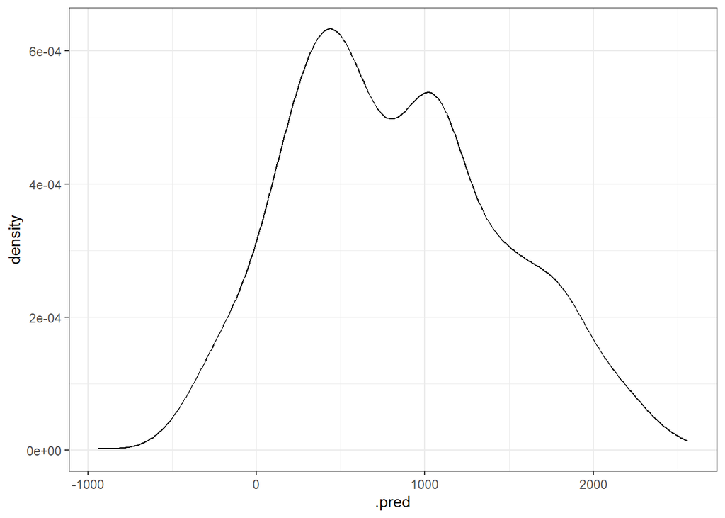

```r
ggplot(divvy_preds, aes(x=.pred)) +
  geom_density()
```

Let’s try to improve the model now

```r
divvy_rec <- recipe(rides ~ ., data=train) %>%
  step_mutate(hour = factor(hour(started_hour)),
              bad_weather = if_else(solar_rad <= 5 & temp <= 5, 1, 0),
              nice_weather = if_else(solar_rad >= 25 & temp >= 15, 1, 0)) %>%
  step_date(started_hour, features=c("dow", "month")) %>%
  step_holiday(started_hour, holidays = timeDate::listHolidays("US"),
               keep_original_cols = FALSE) %>%
  step_unknown(all_nominal_predictors()) %>%
  step_dummy(all_nominal_predictors()) %>%
  step_corr(all_predictors())

divvy_workflow <-
  workflow() %>%
  add_model(lm_model) %>%
  add_recipe(divvy_rec)

divvy_workflow
```

```
## ══ Workflow ════════════════════════════════════════════════════════════════════
## Preprocessor: Recipe
## Model: linear_reg()
##
## ── Preprocessor ────────────────────────────────────────────────────────────────
## 6 Recipe Steps
##
## • step_mutate()
## • step_date()
## • step_holiday()
## • step_unknown()
## • step_dummy()
## • step_corr()
##
## ── Model ───────────────────────────────────────────────────────────────────────
## Linear Regression Model Specification (regression)
##
## Computational engine: lm
```

```r
divvy_fit <- divvy_workflow %>%
  fit(data=train)

divvy_preds <-
  augment(divvy_fit, test, new_data =  test)


yardstick::mape(divvy_preds,
     truth = rides,
     estimate = .pred)
```

| .metric | .estimator | .estimate |
| --- | --- | --- |
| mape | standard | 125.1599 |

```r
yardstick::rmse(divvy_preds,
     truth = rides,
     estimate = .pred)
```

| .metric | .estimator | .estimate |
| --- | --- | --- |
| rmse | standard | 339.5152 |

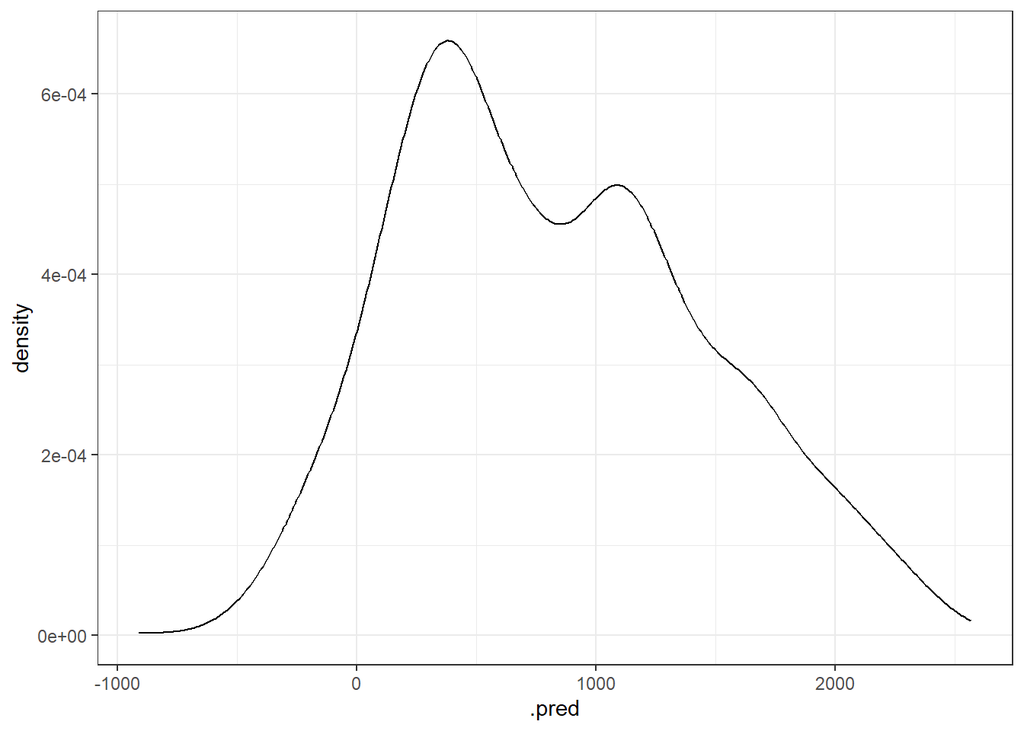

```r
ggplot(divvy_preds, aes(x=.pred)) +
  geom_density()
```

Using decision trees

```r
tree_model <-
  parsnip::decision_tree(tree_depth=5) %>%
  set_engine("rpart") %>%
  set_mode('regression')

divvy_workflow <-
  workflow() %>%
  add_model(tree_model) %>%
  add_recipe(divvy_rec)

divvy_workflow
```

```
## ══ Workflow ════════════════════════════════════════════════════════════════════
## Preprocessor: Recipe
## Model: decision_tree()
##
## ── Preprocessor ────────────────────────────────────────────────────────────────
## 6 Recipe Steps
##
## • step_mutate()
## • step_date()
## • step_holiday()
## • step_unknown()
## • step_dummy()
## • step_corr()
##
## ── Model ───────────────────────────────────────────────────────────────────────
## Decision Tree Model Specification (regression)
##
## Main Arguments:
##   tree_depth = 5
##
## Computational engine: rpart
```

```r
divvy_fit <- divvy_workflow %>%
  fit(data=train)

divvy_preds <-
  augment(divvy_fit, test)


yardstick::mape(divvy_preds,
     truth = rides,
     estimate = .pred)
```

| .metric | .estimator | .estimate |
| --- | --- | --- |
| mape | standard | 421.5899 |

```r
yardstick::rmse(divvy_preds,
     truth = rides,
     estimate = .pred)
```

| .metric | .estimator | .estimate |
| --- | --- | --- |
| rmse | standard | 439.9574 |

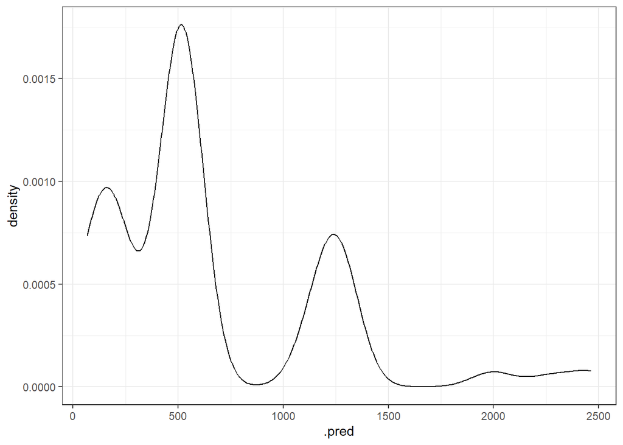

```r
ggplot(divvy_preds, aes(x=.pred)) +
  geom_density()
```

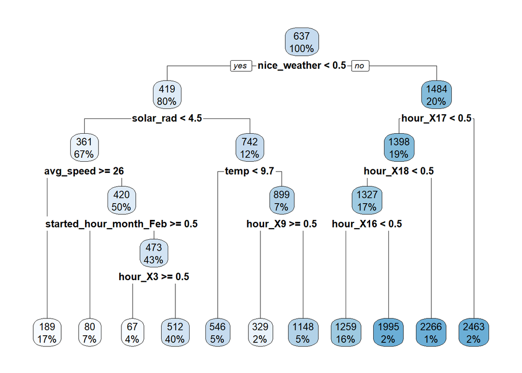

```r
tree_fit <- divvy_fit %>%
  extract_fit_engine()
rpart.plot::rpart.plot(tree_fit)
```